# House Price Prediction in Ankara

**Author:** Dogan Can Senol  
**Project:** M606 - Machine Learning Final Project  
**Dataset:** 100 samples of houses from 8 districts in Ankara  
**Goal:** Predict house prices using machine learning

# 1) Problem Statement

A large real estate company located in Ankara, the capital of Türkiye, wants to develop a machine learning model that can automatically make predictions according to different districts and physical characteristics of the house in order to better analyze the market and offer more accurate prices to its customers. In Türkiye, it can be difficult to make price predictions, especially due to the free market in this area and the excessive pricing of some sellers. Therefore, this necessary project will be carried out to increase customer satisfaction and offer more rational offers to customers compared to competitors. Within the scope of this project, the information of 100 current apartments taken from 8 major districts in Ankara has been turned into a data set and the prediction of house prices has been formulated as a machine learning problem. Since the model will produce numerical output, not categorical, we can say that it is a regression problem.

# 2) Importing Libraries & Loading Dataset

At this stage, the libraries required for the entire analysis of the required data set were loaded and the csv file of the data belonging to 100 houses in 8 large districts in Ankara, the capital of Türkiye, was loaded.

```python
import pandas as pd
import numpy as np
import matplotlib.pyplot as plt
import seaborn as sns

from sklearn.model_selection import train_test_split
from sklearn.preprocessing import LabelEncoder, StandardScaler
from sklearn.metrics import mean_absolute_error, mean_squared_error, r2_score
from sklearn.linear_model import LinearRegression
from sklearn.ensemble import RandomForestRegressor
from sklearn.neighbors import KNeighborsRegressor
```

```python
df = pd.read_csv("machine_learning_project_datasett.csv", sep=";")
```

```python
df.head() # We display the first 5 data of the data set.
```

|  | location | area_m2 | hall_count | room_count | building_age | floor_number | bathroom_count | has_balcony | is_in_site | has_elevator | price |
| --- | --- | --- | --- | --- | --- | --- | --- | --- | --- | --- | --- |
| 0 | Golbasi | 150 | 1 | 3 | 4 | 16 | 2 | yes | yes | yes | 12950000 |
| 1 | Mamak | 125 | 1 | 3 | 4 | 4 | 2 | yes | yes | yes | 3340000 |
| 2 | Cankaya | 130 | 1 | 3 | 33 | 3 | 1 | yes | no | no | 4875000 |
| 3 | Cankaya | 105 | 1 | 3 | 28 | 0 | 1 | yes | no | no | 3075000 |
| 4 | Yenimahalle | 250 | 1 | 5 | 0 | 7 | 3 | yes | yes | yes | 7700000 |

```python
# We examine the row and column numbers in the dataframe we created.
print("Shape:", df.shape)
```

```
Shape: (100, 11)
```

```python
df.describe()
```

|  | area_m2 | hall_count | room_count | building_age | floor_number | bathroom_count | price |
| --- | --- | --- | --- | --- | --- | --- | --- |
| count | 100.00000 | 100.0 | 100.000000 | 100.000000 | 100.000000 | 100.000000 | 1.000000e+02 |
| mean | 134.19000 | 1.0 | 2.840000 | 8.690000 | 3.250000 | 1.460000 | 4.259550e+06 |
| std | 51.33288 | 0.0 | 1.098392 | 9.816184 | 4.482007 | 0.558135 | 2.297567e+06 |
| min | 45.00000 | 1.0 | 1.000000 | 0.000000 | 0.000000 | 1.000000 | 1.090000e+06 |
| 25% | 102.25000 | 1.0 | 2.000000 | 0.000000 | 1.000000 | 1.000000 | 2.750000e+06 |
| 50% | 130.00000 | 1.0 | 3.000000 | 5.000000 | 2.000000 | 1.000000 | 3.565000e+06 |
| 75% | 155.00000 | 1.0 | 3.000000 | 15.000000 | 4.000000 | 2.000000 | 5.036750e+06 |
| max | 300.00000 | 1.0 | 6.000000 | 35.000000 | 24.000000 | 3.000000 | 1.295000e+07 |

Explanation: With the code "df.describe()" we access statistical values such as the minimum and maximum values of the columns in our dataframe and their averages. If we look at this table, we can see that the area of the largest house in the data is 300 square meters and the smallest house is 45 square meters. Similarly, it can be easily seen that the average building age is 8.69 and the standard deviation is 9.82.

# 3) Exploratory Data Analysis (EDA)

In this section, statistics and visualizations were used to better understand the data structure, better analyze the dataset, and identify potential errors and omissions.

```python
# We check data types and whether there is missing data!
df.info()
```

```
<class 'pandas.core.frame.DataFrame'>
RangeIndex: 100 entries, 0 to 99
Data columns (total 11 columns):
 #   Column          Non-Null Count  Dtype
---  ------          --------------  -----
 0   location        100 non-null    object
 1    area_m2        100 non-null    int64
 2    hall_count     100 non-null    int64
 3   room_count      100 non-null    int64
 4   building_age    100 non-null    int64
 5   floor_number    100 non-null    int64
 6   bathroom_count  100 non-null    int64
 7   has_balcony     100 non-null    object
 8   is_in_site      100 non-null    object
 9   has_elevator    100 non-null    object
 10  price           100 non-null    int64
dtypes: int64(7), object(4)
memory usage: 8.7+ KB
```

According to the information we have obtained, we do not have any missing data. Also, it is seen which variable type the columns are.

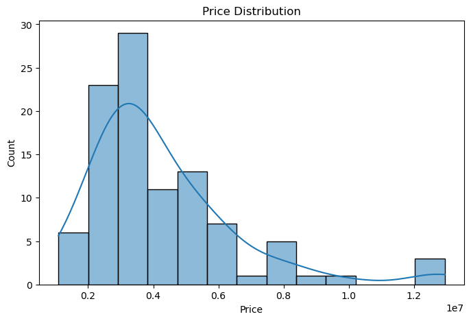

```python
# Target Variable (price) Distribution
plt.figure(figsize=(8,5))
sns.histplot(df['price'], kde=True)
plt.title("Price Distribution")
plt.xlabel("Price")
plt.ylabel("Count")
plt.show()
```

This graph shows the distribution of prices of houses in the dataset. We can see that the prices of most houses are concentrated at low levels. It is seen that they are concentrated especially between 2 and 4 million liras. It can be seen that there are few houses with higher prices. This graph shows that it would be more logical to examine the median value instead of the average value. Because a few examples with extremely high prices, even if they are few in number, will increase the average.

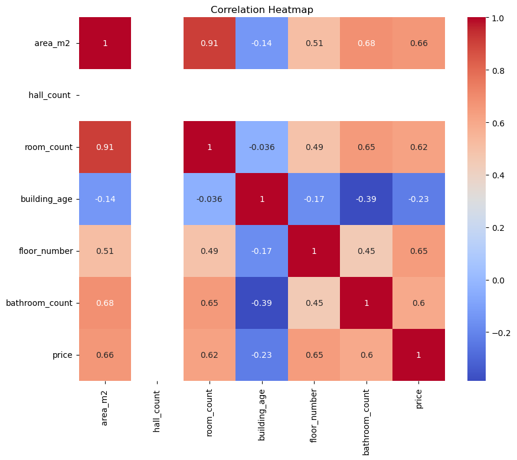

```python
# Correlation Heat Map
plt.figure(figsize=(10,8))
sns.heatmap(df.corr(numeric_only=True), annot=True, cmap='coolwarm')
plt.title("Correlation Heatmap")
plt.show()
```

First, we can start by examining how the features affect our target variable (housing price) on this map. The highest correlation was 0.66 in the area of the house (area_m2). This means that as the house grows, there is an increase in the price of the house. Similarly, the number of rooms (room_count), the floor it is on (floor_number) and the number of bathrooms (bathroom_count) show that the price of the house increases positively. If we look at the age of the building, we see that the correlation is -0.23, which is negative. This means that as the age of the building increases, the price starts to decrease. In addition, since the number of halls (hall_count) is 1 in all examples, we cannot reach a conclusion about how it affects the price. If we look at the correlations between the features; the correlation between "area_m2" and "room_count" is 0.91. In other words, it is seen that as the area of the house grows, the number of rooms increases. Similarly, when we look at the correlation between "room_count" and "bathroom_count", we can see that it is 0.65. This means that as the number of rooms increases, the number of bathrooms increases. As a result, "area_m2", "room_count", "bathroom_count" and "floor_number" are quite effective on the price. The age of the building is inversely proportional to the price and we cannot comment on the number of rooms.

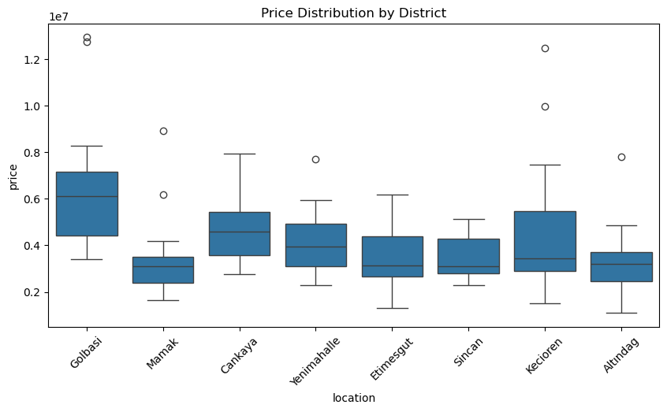

```python
# Price Distribution Based on Location
plt.figure(figsize=(10,5))
sns.boxplot(data=df, x='location', y='price')
plt.title("Price Distribution by District")
plt.xticks(rotation=45)
plt.show()
```

When we look at this graph, we can examine how the price is distributed by region. For example, when we look at the Gölbasi region, we can see that it has the highest median price. Although there are a few extreme values with a price of 13 million lira, we can see that the prices are generally very high. This is truly a luxurious region. On the contrary, when we look at the Mamak region, we can see that it has low-priced houses. The median seems to be around 3 million. When we look at the Cankaya region, we can see that there is no extreme value and that the prices are very evenly distributed. It can be said that the Kecioren region is a mixed region with both expensive and cheap houses. It can be said that the prices for other regions are generally between 3 and 4 million and the prices are medium-level. As a result, it is possible to say that location is an important variable affecting the price.

```python
df.columns = df.columns.str.strip() # This code was added as a result of an error received during the execution of the code. It removes the leading and trailing spaces in all column names.
```

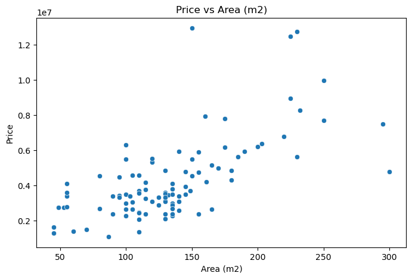

```python
# Examining the relationship between area and price.
plt.figure(figsize=(8,5))
sns.scatterplot(data=df, x='area_m2', y='price')
plt.title("Price vs Area (m2)")
plt.xlabel("Area (m2)")
plt.ylabel("Price")
plt.show()
```

The graph shows the relationship between the area of the house and its price. In general, we see that the price increases as the area increases. In other words, there seems to be a linearity. Houses are generally between 100-150 square meters and the price diversity is very high in this range. Some exceptional cases are seen in the graph. For example, there is a house that is 13 million despite being 150 square meters. This shows that the house has different and prominent features than the general examples. As a result, it is clear that the "area_m2" feature is a strong feature and is expected to make a great contribution to price estimation.

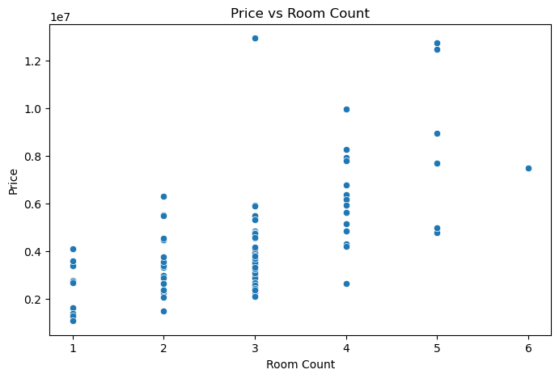

```python
# Plotting the relationship between number of rooms and price
plt.figure(figsize=(8,5))
sns.scatterplot(data=df, x='room_count', y='price')
plt.title("Price vs Room Count")
plt.xlabel("Room Count")
plt.ylabel("Price")
plt.show()
```

This graph shows the relationship between the number of rooms in a house and the price of the house. When you look at the graph, you can first see that most houses have 2, 3 or 4 rooms. It is possible to say that the price generally increases as the number of rooms increases, but a completely linear relationship cannot be mentioned. Especially in houses with 4, 5 and 6 rooms, the price is very widespread. In other words, there are both low and high priced examples. Therefore, this feature alone may be difficult to explain the price.

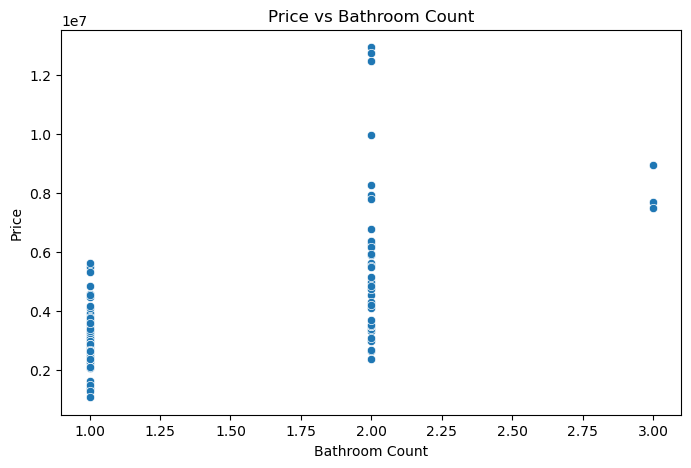

```python
# Plotting the relationship between number of bathrooms and price
plt.figure(figsize=(8,5))
sns.scatterplot(data=df, x='bathroom_count', y='price')
plt.title("Price vs Bathroom Count")
plt.xlabel("Bathroom Count")
plt.ylabel("Price")
plt.show()
```

As seen in the graph, the houses in the dataset have 1, 2 or 3 bathrooms. It is possible to say that houses with 1 bathroom are generally low priced. The price range of houses with 2 bathrooms is quite wide. However, there are very few examples of houses with 3 bathrooms, but it can still be said that their prices are high. The number of bathrooms is related to the overall size and luxury level of the house. Therefore, increasing the number of bathrooms affects the price of the house, albeit slightly. The fact that there are very few examples of houses with 3 bathrooms may cause problems when training the model.

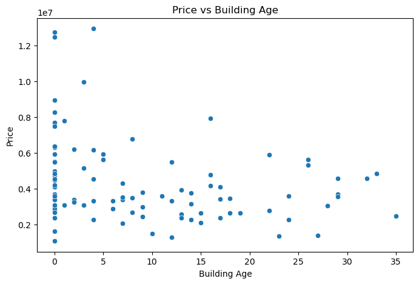

```python
# Plotting the relationship between building age and price.
plt.figure(figsize=(8,5))
sns.scatterplot(data=df, x='building_age', y='price')
plt.title("Price vs Building Age")
plt.xlabel("Building Age")
plt.ylabel("Price")
plt.show()
```

This graph clearly shows that the building age and price are inversely proportional. In general, it is observed that prices decrease as the building age increases. For example, while the price range for newly constructed buildings that are zero years old is between 2 and 13 million, prices for buildings older than 20 years usually do not exceed 6 million. The relationship between the two variables is negative. However, we cannot talk about linearity.

# 4) Data Preprocessing

In this part of the study, we are doing data preprocessing before moving on to our model training. In other words, we can say that we are organizing the data in order to train the model in the best way. At this stage, unnecessary columns are removed, transformations and scaling are done. In addition, one of the most important parts of training the model is dividing the data into "training" and "testing".

```python
df = df.drop('hall_count', axis=1)
```

Here "hall_count" is unimportant. Because it has a fixed (1) value for all data. It does not carry any information.

```python
binary_cols = ['has_balcony', 'is_in_site', 'has_elevator']
df[binary_cols] = df[binary_cols].replace({'yes': 1, 'no': 0})
```

```
C:\Users\dogan\AppData\Local\Temp\ipykernel_2064\3278648470.py:2: FutureWarning: Downcasting behavior in `replace` is deprecated and will be removed in a future version. To retain the old behavior, explicitly call `result.infer_objects(copy=False)`. To opt-in to the future behavior, set `pd.set_opti…
  df[binary_cols] = df[binary_cols].replace({'yes': 1, 'no': 0})
```

We received a warning here. It indicates that we converted our object type columns to 1 and 0.

```python
df = pd.get_dummies(df, columns=['location'], drop_first=True)
```

Here, with the "drop_first=True" command, we remove the first category, that is, one of the districts, and take this category as a reference. In other words, if we know the remaining seven regions, we can predict the eighth region. This creates a linear dependency.

```python
X = df.drop('price', axis=1) # For all columns except price to be independent variables
y = df['price'] # Target variable

# Splitting the dataset into training and test.
from sklearn.model_selection import train_test_split
X_train, X_test, y_train, y_test = train_test_split(X, y, test_size=0.2, random_state=42)
```

At this stage, we divide our data into two sets: training and testing. 80% training, 20% testing. We use the "random_state=42" parameter to avoid getting different results in each run. In other words, we use it to test a data with the same model over and over again. The number 42 is not important, it can be written in any other number.

```python
# Scaling real number columns

from sklearn.preprocessing import StandardScaler

numeric_features = ['area_m2', 'room_count', 'building_age', 'floor_number', 'bathroom_count']

scaler = StandardScaler()
X_train[numeric_features] = scaler.fit_transform(X_train[numeric_features])
X_test[numeric_features] = scaler.transform(X_test[numeric_features])
```

# 5) Model Training and Testing

```python
# Building and training our model
lr_model = LinearRegression()
lr_model.fit(X_train, y_train)

# We make predictions with test data
y_pred_lr = lr_model.predict(X_test)

# We calculate performance metrics
mae_lr = mean_absolute_error(y_test, y_pred_lr)
rmse_lr = np.sqrt(mean_squared_error(y_test, y_pred_lr))
r2_lr = r2_score(y_test, y_pred_lr)

# Results
print("Linear Regression Performance:")
print(f"MAE  : {mae_lr:.2f}")
print(f"RMSE : {rmse_lr:.2f}")
print(f"R²   : {r2_lr:.4f}")
```

```
Linear Regression Performance:
MAE  : 864887.31
RMSE : 1318810.53
R²   : 0.7241
```

When we look at the MAE value, we see that the average error is 864,887 Turkish lira. In other words, the linear regression model predicts house prices with this much deviation on average. Similarly, when we examine the RMSE value, we see that it is 1,318,810 Turkish lira. In other words, the root mean square of the errors is higher than the MAE. This can be considered a normal situation because it is more sensitive to large errors. Finally, when we look at the R square value, we are faced with a value of 0.7241. This metric is very important for us. Because it shows that the model can explain 72.41% of the price change.

```python
# This time we are training our Random forest model
rf_model = RandomForestRegressor(random_state=42)
rf_model.fit(X_train, y_train)

# Prediction
y_pred_rf = rf_model.predict(X_test)

# We calculate performance metrics for RandomForest
mae_rf = mean_absolute_error(y_test, y_pred_rf)
rmse_rf = np.sqrt(mean_squared_error(y_test, y_pred_rf))
r2_rf = r2_score(y_test, y_pred_rf)

# Results
print("Random Forest Performance:")
print(f"MAE  : {mae_rf:.2f}")
print(f"RMSE : {rmse_rf:.2f}")
print(f"R²   : {r2_rf:.4f}")
```

```
Random Forest Performance:
MAE  : 1155725.00
RMSE : 1940560.95
R²   : 0.4025
```

When we look at this model, we see that the errors are larger and the model can only explain 40% of the variance. The fact that there is not enough data and therefore the model has not been trained sufficiently may be the most important reason for these results. Because the Random Forest model can give more reliable results if it is trained with more data. It is possible to say that the Linear Regression model performs much better than the Random Forest.

```python
# Create our model
knn_model = KNeighborsRegressor()
knn_model.fit(X_train, y_train)

# Predictions
y_pred_knn = knn_model.predict(X_test)

# Calculate metrics for KNeighbors
mae_knn = mean_absolute_error(y_test, y_pred_knn)
rmse_knn = np.sqrt(mean_squared_error(y_test, y_pred_knn))
r2_knn = r2_score(y_test, y_pred_knn)

# Results
print("KNN Regressor Performance:")
print(f"MAE  : {mae_knn:.2f}")
print(f"RMSE : {rmse_knn:.2f}")
print(f"R²   : {r2_knn:.4f}")
```

```
KNN Regressor Performance:
MAE  : 1209700.00
RMSE : 1679037.45
R²   : 0.5527
```

# 6) Feature Engineering

In this phase of the task, we will apply "Future Engineering" to change the results we obtained and obtain better results. It is expected that the models will be more successful in prediction, especially when we determine the price per square meter rather than on a house-by-house basis or when we divide the building age into certain groups rather than separately.

```python
# Price per square meter
df['price_per_m2'] = df['price'] / df['area_m2']
```

```python
# Create binary column: 1 if building is 5 years old or newer
df['is_new_building'] = (df['building_age'] <= 5).astype(int)
```

```python
# Let's group the building age
df['age_group'] = pd.cut(df['building_age'], bins=[-1, 5, 15, 30, np.inf], labels=['0-5', '6-15', '16-30', '30+'])
```

```python
df = pd.get_dummies(df, columns=['age_group'], drop_first=True)
```

# 7) Preprocessing (After Future Engineering)

This stage is actually the process of reprocessing the data and making it ready for training and testing processes, as we have made some changes to our dataframe.

```python
X = df.drop('price', axis=1)
y = df['price']

from sklearn.model_selection import train_test_split
X_train, X_test, y_train, y_test = train_test_split(X, y, test_size=0.2, random_state=42)

# We are rescaling
from sklearn.preprocessing import StandardScaler
numeric_features = ['area_m2', 'room_count', 'building_age', 'floor_number', 'bathroom_count']

scaler = StandardScaler()
X_train[numeric_features] = scaler.fit_transform(X_train[numeric_features])
X_test[numeric_features] = scaler.transform(X_test[numeric_features])
```

# 8) Model Retraining (After Feature Engineering)

In this section, we retrain our data that we applied "Future Engineering" to and reprocessed. We will retrain the same three models and look at the results.

```python
lr_model = LinearRegression()
lr_model.fit(X_train, y_train)

y_pred_lr = lr_model.predict(X_test)

mae_lr = mean_absolute_error(y_test, y_pred_lr)
rmse_lr = np.sqrt(mean_squared_error(y_test, y_pred_lr))
r2_lr = r2_score(y_test, y_pred_lr)

print("Linear Regression (After Feature Engineering):")
print(f"MAE  : {mae_lr:.2f}")
print(f"RMSE : {rmse_lr:.2f}")
print(f"R²   : {r2_lr:.4f}")
```

```
Linear Regression (After Feature Engineering):
MAE  : 944127.08
RMSE : 1354326.31
R²   : 0.7090
```

```python
rf_model = RandomForestRegressor(random_state=42)
rf_model.fit(X_train, y_train)

y_pred_rf = rf_model.predict(X_test)

mae_rf = mean_absolute_error(y_test, y_pred_rf)
rmse_rf = np.sqrt(mean_squared_error(y_test, y_pred_rf))
r2_rf = r2_score(y_test, y_pred_rf)

print("Random Forest (After Feature Engineering):")
print(f"MAE  : {mae_rf:.2f}")
print(f"RMSE : {rmse_rf:.2f}")
print(f"R²   : {r2_rf:.4f}")
```

```
Random Forest (After Feature Engineering):
MAE  : 1189558.50
RMSE : 1977079.21
R²   : 0.3798
```

```python
knn_model = KNeighborsRegressor()
knn_model.fit(X_train, y_train)

y_pred_knn = knn_model.predict(X_test)

mae_knn = mean_absolute_error(y_test, y_pred_knn)
rmse_knn = np.sqrt(mean_squared_error(y_test, y_pred_knn))
r2_knn = r2_score(y_test, y_pred_knn)

print("KNN Regressor (After Feature Engineering):")
print(f"MAE  : {mae_knn:.2f}")
print(f"RMSE : {rmse_knn:.2f}")
print(f"R²   : {r2_knn:.4f}")
```

```
KNN Regressor (After Feature Engineering):
MAE  : 1223050.00
RMSE : 1690596.56
R²   : 0.5465
```

If we make a general evaluation, it seems that the Future engineering section did not work very well. When we examine the results, we see that the "MAE" and "RMSE" values increased; the R-square value decreased in all of them, albeit slightly. The reason for this decrease in the linear regression model may be that the categorical features we added did not have a linear relationship. Actually, what was expected was an increase for the Random Forest model rather than Linear Regression. However, there is a similar decline in that. We can attribute this to the small data set. Because the Random Forest model produces more successful results in large data sets. The newly added columns may have made the model more complex. It seems possible to say that it is neutral for KNN.

# 9) Model Performance Comparison

This section includes the comparison of the trained and tested models after future engineering.

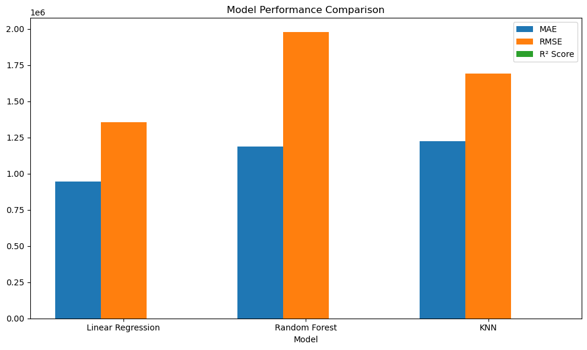

```python
models = ['Linear Regression', 'Random Forest', 'KNN']
mae_scores = [944127.08, 1189558.50, 1223050.00]
rmse_scores = [1354326.31, 1977079.21, 1690596.56]
r2_scores = [0.7090, 0.3798, 0.5465]

x = np.arange(len(models))
width = 0.25

plt.figure(figsize=(10,6))
plt.bar(x - width, mae_scores, width, label='MAE')
plt.bar(x, rmse_scores, width, label='RMSE')
plt.bar(x + width, r2_scores, width, label='R² Score')

plt.xlabel('Model')
plt.title('Model Performance Comparison')
plt.xticks(x, models)
plt.legend()
plt.tight_layout()
plt.show()
```

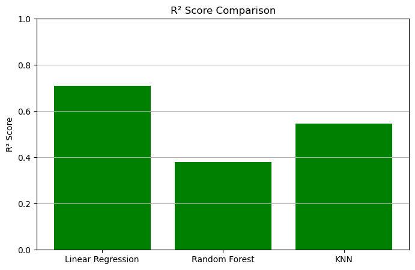

```python
plt.figure(figsize=(8,5))
plt.bar(models, r2_scores, color='green')
plt.title("R² Score Comparison")
plt.ylabel("R² Score")
plt.ylim(0, 1)
plt.grid(axis='y')
plt.show()
```

The R-Square comparison was examined as a separate graph. The Linear Regression model was the model with the highest value. It can explain more than 70% of the price change in the data set. We can say that the other two models are a bit more unsuccessful. At this point, we can say that the structure of the Linear Regression model and the data match is not bad.

# 10) Conclusion

In this project, it was aimed to predict house prices using a dataset consisting of 100 samples from 8 different districts in Ankara. Machine learning processes such as data preprocessing, exploratory data analysis, feature engineering, modeling and model evaluation were completed. Three different regression models were used, namely "Linear Regression", "Random Forest Regressor", "K-Nearest Neighbors Regressor". As a result of the comparisons made, the linear regression model showed the best performance in all metrics. This model reached the lowest MAE and RMSE values. It also reached the highest R-Square value and successfully explained 70%+ of price changes. It should be said that the feature engineering part did not benefit much. Although new variables and categorical groupings were added, these features did not improve the model performance. In general, it can be concluded that the Linear Regression model did not do a bad job on a dataset with little data.